# Suivi démarche Connecte

Equipe développement SGDF

21 juillet 2019

[figure not shown]

Ce document a pour objet d’assurer le suivi de la démarche Connecte. Celle-ci se veut être une démarche d’ouverture et developpement, en vue du Jamboree Connecte et en s’en servant comme support de communication et outil d’attractivité.

## Evolution des inscriptions par semaine

Les deux graphiques suivants montrent :

- pour le premier le volume d’inscription hebdomadaire ;
- pour le second le volume cumulé d’inscription hebdomadaire, comparé à la moyenne des cinq dernières années (en pointillé).

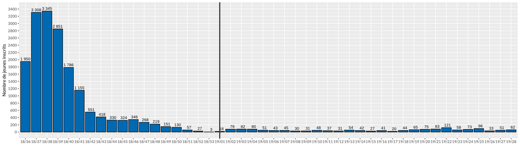

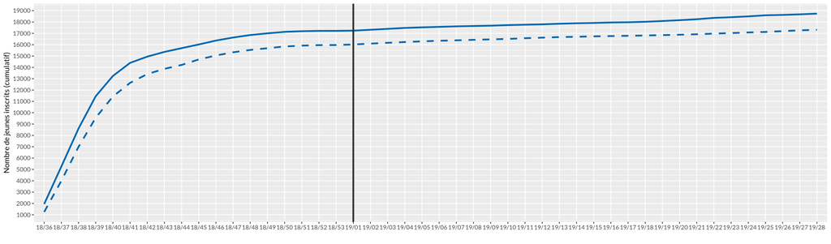

## Suivi par rapport aux pré-inscriptions

| Participation au défi++ | Annonce défi ++ | Nombre de nouveaux jeunes depuis janvier |
| --- | --- | --- |
| Non | 0 | 487 |
| Oui | 1232 | 711 |
| Pas d’inscription à Connecte | 0 | 214 |

## Evolution des effectifs par tribu

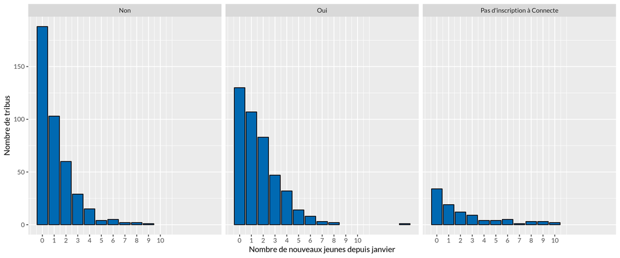

## Suivi des tribus n’existant pas en janvier

| Code structure | Nom de la structure | Nombre de jeunes inscrits |
| --- | --- | --- |
| 109223921 | 1ERE SCOUTS GUIDES MAR MAROUN - ST SAUVEUR | 3 |
| 407303321 | SCOUTS GUIDES - LEMAN BAS CHABLAIS | 1 |
| 601100321 | SCOUTS GUIDES NARBONNE | 1 |
| 603000222 | SCOUTS NIMES | 3 |
| 804101121 | 1ERE SCOUTS LE GOSIER | 3 |
| 804102821 | SCOUTS-GUIDES | 5 |
| 119104221 | SCOUTS - EPINAY VAL D’YERRES | 3 |

## Dimension territoriale

On regarde par territoire, où la part des jeunes inscrits depuis janvier est la plus forte.

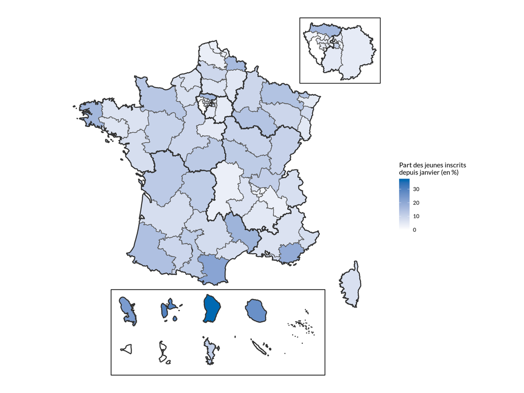

En résumé, par centre de ressources :

|  | Nombre de jeunes dernier comptage | Différence depuis début janvier | Evolution depuis début janvier (en %) |
| --- | --- | --- | --- |
| CR Centre est | 3 400 | 204 | 6,0 |
| CR Île-de-France Est | 2 727 | 150 | 5,5 |
| CR Île-de-France Ouest | 2 576 | 115 | 4,5 |
| CR Méditerranée | 1 171 | 101 | 8,6 |
| CR Nord | 1 826 | 110 | 6,0 |
| CR Nord-est | 1 506 | 132 | 8,8 |
| CR Ouest | 2 797 | 245 | 8,8 |
| CR Outre-mer Monde | 759 | 147 | 19,4 |
| CR Sud ouest | 1 976 | 208 | 10,5 |
| Total | 18 738 | 1 412 | 7,5 |

## Télécharger les données détaillées

Download Suivi_Connecte_detail_2019_29.xlsx

> **Méthodologie**

> Les fichiers exploités correspondent à la mise en forme des flux de l’Intranet par l’équipe développement.

> L’analyse consiste principalement à mettre en regard les évolutions actuelles du nombre de jeunes par rapport aux évolutions de longue période d’un coté et à une période de référence de l’autre, afin de faire ressortir d’éventuels effets dus aux démarches d’ouverture.